# Problem Set 3: Diamonds

This is a file to solve all the excercises of **Problem Set 3: Diamonds** from Udacity’s Course: Data Analysis with R.

### Frist Excercise:

Basic exploration of Diamonds data set.

```r
library(ggplot2)
data(diamonds)

dim(diamonds) # 53940 obs and 10 variables
```

```
## [1] 53940    10
```

```r
str(diamonds) # 3 Ordered Factors
```

```
## 'data.frame':    53940 obs. of  10 variables:
##  $ carat  : num  0.23 0.21 0.23 0.29 0.31 0.24 0.24 0.26 0.22 0.23 ...
##  $ cut    : Ord.factor w/ 5 levels "Fair"<"Good"<..: 5 4 2 4 2 3 3 3 1 3 ...
##  $ color  : Ord.factor w/ 7 levels "D"<"E"<"F"<"G"<..: 2 2 2 6 7 7 6 5 2 5 ...
##  $ clarity: Ord.factor w/ 8 levels "I1"<"SI2"<"SI1"<..: 2 3 5 4 2 6 7 3 4 5 ...
##  $ depth  : num  61.5 59.8 56.9 62.4 63.3 62.8 62.3 61.9 65.1 59.4 ...
##  $ table  : num  55 61 65 58 58 57 57 55 61 61 ...
##  $ price  : int  326 326 327 334 335 336 336 337 337 338 ...
##  $ x      : num  3.95 3.89 4.05 4.2 4.34 3.94 3.95 4.07 3.87 4 ...
##  $ y      : num  3.98 3.84 4.07 4.23 4.35 3.96 3.98 4.11 3.78 4.05 ...
##  $ z      : num  2.43 2.31 2.31 2.63 2.75 2.48 2.47 2.53 2.49 2.39 ...
```

```r
str(diamonds$color)
```

```
##  Ord.factor w/ 7 levels "D"<"E"<"F"<"G"<..: 2 2 2 6 7 7 6 5 2 5 ...
```

```r
?diamonds # D Represents the best Color
```

### Second Excercise:

Create a histogram of the price of all the diamonds in the diamond data set.

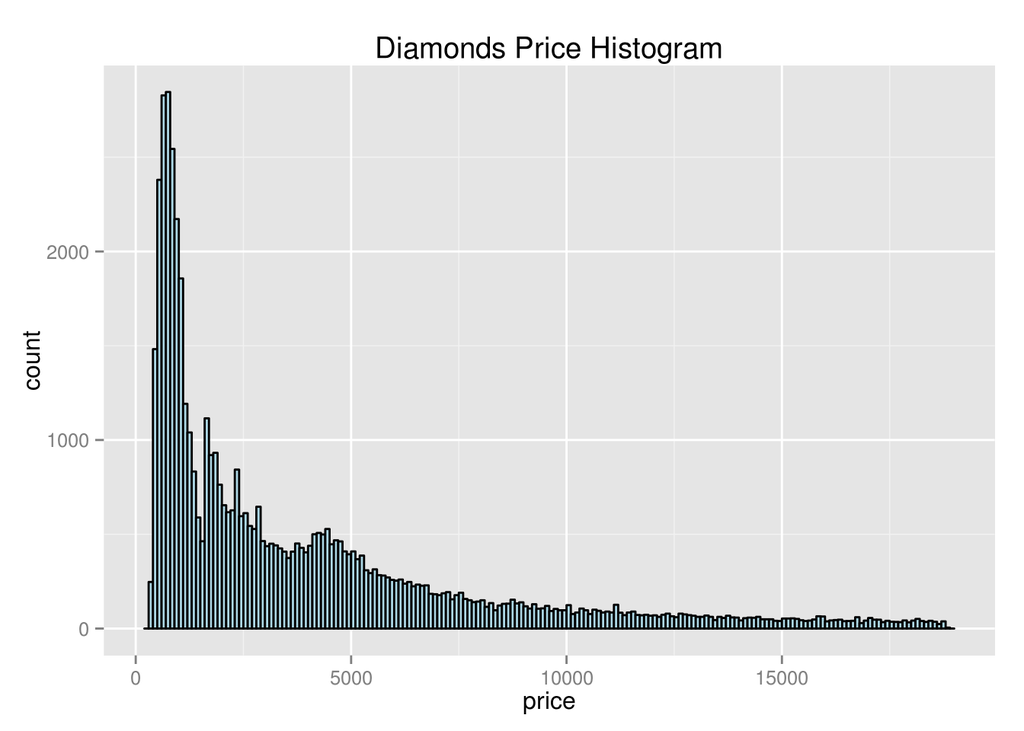

```r
ggplot(diamonds) + geom_histogram(aes(x=price), binwidth = 100,
                                  color = "black", fill = "lightblue") +
  ggtitle("Diamonds Price Histogram")
```

### Excercise 3:

Describe the shape and center of the price distribution. Include summary statistics like the mean and median

```r
summary(diamonds$price)
```

```
##    Min. 1st Qu.  Median    Mean 3rd Qu.    Max.
##     326     950    2401    3933    5324   18820
```

The shape of the distribution is **Skewed Right** with its **center in 2401**. I chose the Median as center due to the long tail of the graph. The mean of the distribution is 3933.

### Excercise 4: Diamond Counts

How many diamonds cost less than $500?

```r
nrow(subset(diamonds, price < 500))
```

```
## [1] 1729
```

How many diamonds cost less than $250?

```r
nrow(subset(diamonds, price < 250))
```

```
## [1] 0
```

How many diamonds cost $15000 or more?

```r
nrow(subset(diamonds, price >= 15000))
```

```
## [1] 1656
```

### Excercise 5: Exploring the Peak

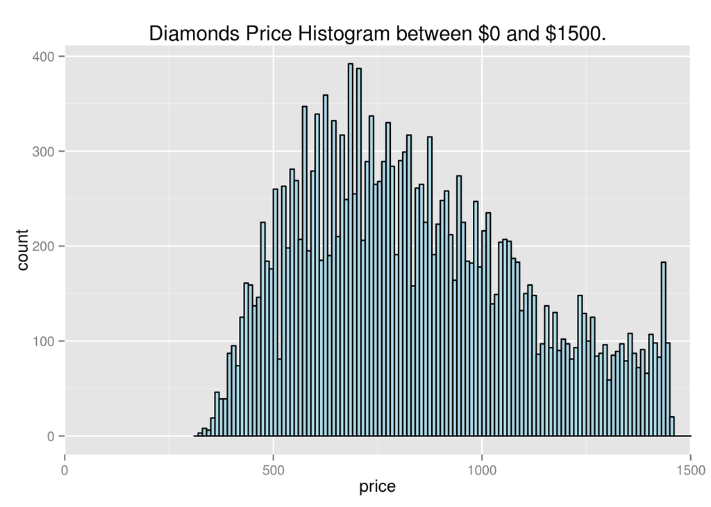

```r
ggplot(diamonds) + geom_histogram(aes(x=price), binwidth = 10,
                                  color = "black", fill = "lightblue") +
  ggtitle("Diamonds Price Histogram between $0 and $1500.") +
  coord_cartesian(xlim=c(0,1500))
```

### Excercise 6: Price by cut histogram

Break out the histogram of diamond prices by cut. You should have five histograms in separate panels on your resulting plot.

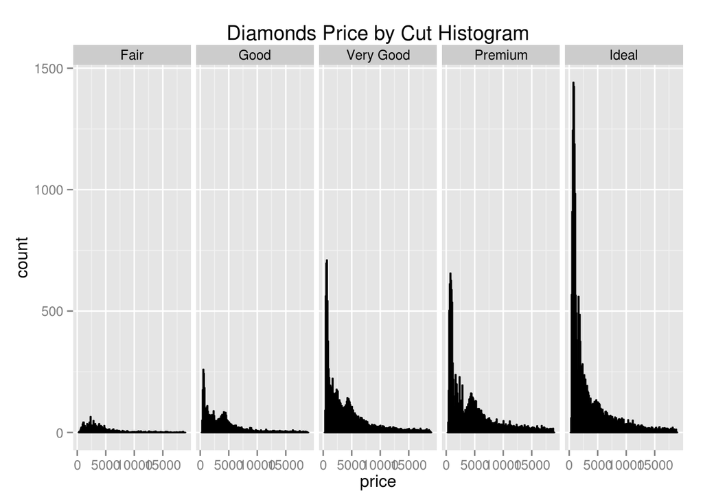

```r
ggplot(diamonds) + geom_histogram(aes(x=price), binwidth = 100,
                                  color = "black", fill = "lightblue") +
  ggtitle("Diamonds Price by Cut Histogram") +
  facet_grid(. ~ cut)
```

### Excercise 7: Price by Cut

Answer the question below. Check more than one option if there are ties.

Which cut has the highest priced diamond?

```r
diamonds[which.max(diamonds$price),]
```

```
##       carat     cut color clarity depth table price   x    y    z
## 27750  2.29 Premium     I     VS2  60.8    60 18823 8.5 8.47 5.16
```

```r
#or
summary(diamonds$price) # Max = 18820
```

```
##    Min. 1st Qu.  Median    Mean 3rd Qu.    Max.
##     326     950    2401    3933    5324   18820
```

```r
diamonds[diamonds$price == 18823,] # 18820 doesn't exist!?!?!?
```

```
##       carat     cut color clarity depth table price   x    y    z
## 27750  2.29 Premium     I     VS2  60.8    60 18823 8.5 8.47 5.16
```

Which cut has the lowest priced diamond?

```r
which.min(diamonds$price)
```

```
## [1] 1
```

```r
# or
summary(diamonds$price) # Min = 326
```

```
##    Min. 1st Qu.  Median    Mean 3rd Qu.    Max.
##     326     950    2401    3933    5324   18820
```

```r
diamonds[diamonds$price == 326,]
```

```
##   carat     cut color clarity depth table price    x    y    z
## 1  0.23   Ideal     E     SI2  61.5    55   326 3.95 3.98 2.43
## 2  0.21 Premium     E     SI1  59.8    61   326 3.89 3.84 2.31
```

Which cut has the lowest median price?

```r
by(diamonds$price,diamonds$cut,summary)
```

```
## diamonds$cut: Fair
##    Min. 1st Qu.  Median    Mean 3rd Qu.    Max.
##     337    2050    3282    4359    5206   18570
## --------------------------------------------------------
## diamonds$cut: Good
##    Min. 1st Qu.  Median    Mean 3rd Qu.    Max.
##     327    1145    3050    3929    5028   18790
## --------------------------------------------------------
## diamonds$cut: Very Good
##    Min. 1st Qu.  Median    Mean 3rd Qu.    Max.
##     336     912    2648    3982    5373   18820
## --------------------------------------------------------
## diamonds$cut: Premium
##    Min. 1st Qu.  Median    Mean 3rd Qu.    Max.
##     326    1046    3185    4584    6296   18820
## --------------------------------------------------------
## diamonds$cut: Ideal
##    Min. 1st Qu.  Median    Mean 3rd Qu.    Max.
##     326     878    1810    3458    4678   18810
```

### Excercise 8: Scales and Multiple Histograms

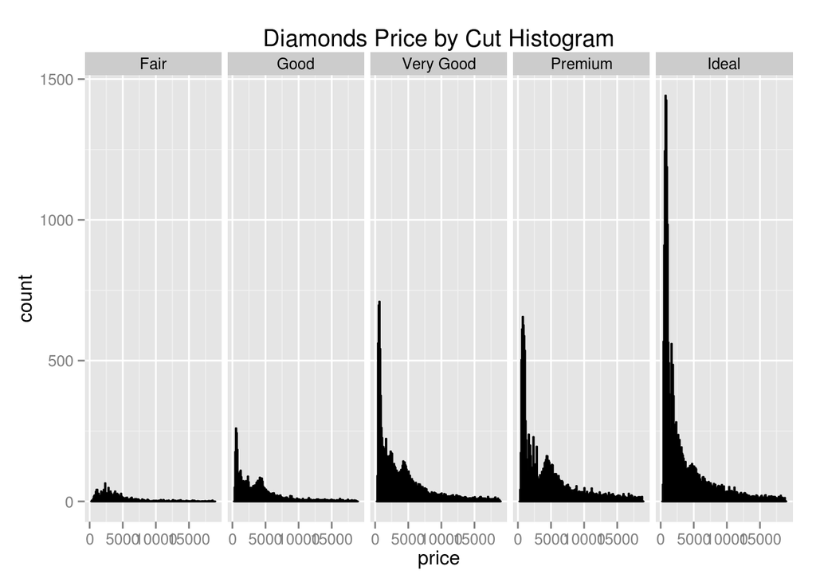

```r
ggplot(diamonds) + geom_histogram(aes(x=price), binwidth = 100,
                                  color = "black", fill = "lightblue") +
  ggtitle("Diamonds Price by Cut Histogram") +
  facet_grid(. ~ cut)
```

```
## stat_bin: binwidth defaulted to range/30. Use 'binwidth = x' to adjust this.
## stat_bin: binwidth defaulted to range/30. Use 'binwidth = x' to adjust this.
## stat_bin: binwidth defaulted to range/30. Use 'binwidth = x' to adjust this.
## stat_bin: binwidth defaulted to range/30. Use 'binwidth = x' to adjust this.
## stat_bin: binwidth defaulted to range/30. Use 'binwidth = x' to adjust this.
```

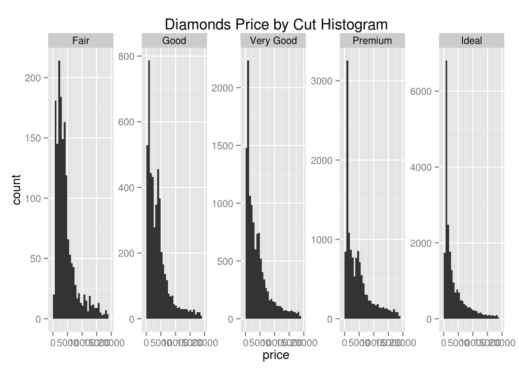

```r
ggplot(diamonds) + geom_histogram(aes(x=price)) +
  ggtitle("Diamonds Price by Cut Histogram") +
  facet_wrap(~ cut,scales="free_y",ncol = 5)
```

```
## stat_bin: binwidth defaulted to range/30. Use 'binwidth = x' to adjust this.
## stat_bin: binwidth defaulted to range/30. Use 'binwidth = x' to adjust this.
## stat_bin: binwidth defaulted to range/30. Use 'binwidth = x' to adjust this.
## stat_bin: binwidth defaulted to range/30. Use 'binwidth = x' to adjust this.
## stat_bin: binwidth defaulted to range/30. Use 'binwidth = x' to adjust this.
```

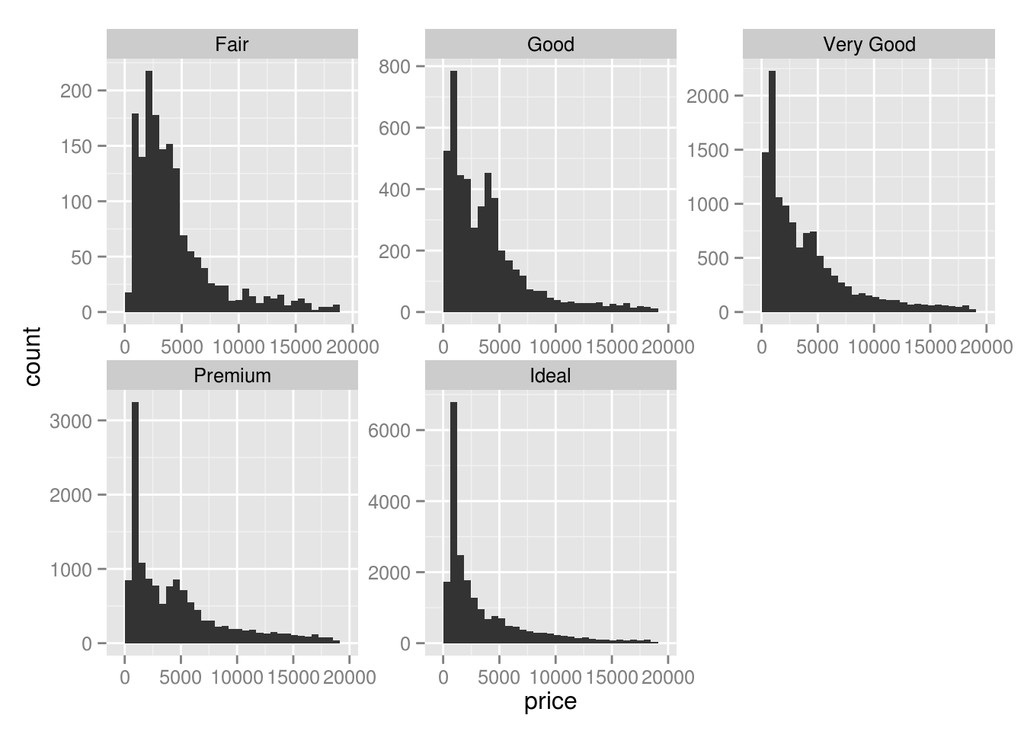

```r
qplot(x = price, data = diamonds) + facet_wrap(~cut, scales="free")
```

### Excercise 9: Price per Carat by Cut

Create a histogram of price per carat and facet it by cut. You can make adjustments to the code from the previous exercise to get started.

Adjust the bin width and transform the scale of the x-axis using log10.

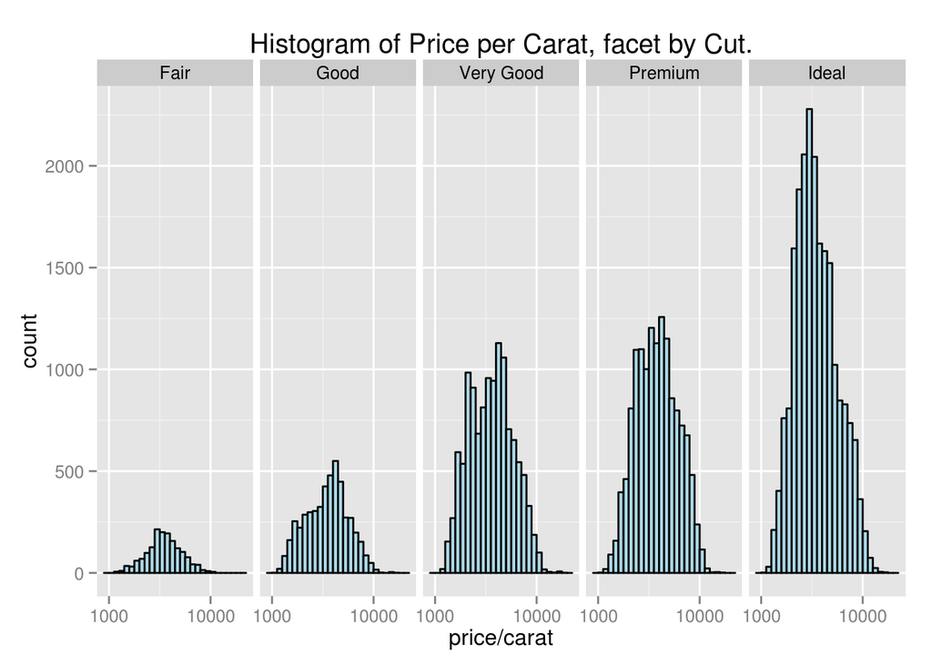

```r
ggplot(diamonds) + geom_histogram(aes(x=price/carat), binwidth = 0.05,
                                  color = "black", fill = "lightblue") +
  ggtitle("Histogram of Price per Carat, facet by Cut.") +
  scale_x_log10() +
  facet_grid(. ~ cut)
```

### Excercise 10: Price Box Plots

Investigate the price of diamonds using box plots, numerical summaries, and one of the following categorical variables: cut, clarity, or color.

```r
by(diamonds$price, diamonds$color, summary)
```

```
## diamonds$color: D
##    Min. 1st Qu.  Median    Mean 3rd Qu.    Max.
##     357     911    1838    3170    4214   18690
## --------------------------------------------------------
## diamonds$color: E
##    Min. 1st Qu.  Median    Mean 3rd Qu.    Max.
##     326     882    1739    3077    4003   18730
## --------------------------------------------------------
## diamonds$color: F
##    Min. 1st Qu.  Median    Mean 3rd Qu.    Max.
##     342     982    2344    3725    4868   18790
## --------------------------------------------------------
## diamonds$color: G
##    Min. 1st Qu.  Median    Mean 3rd Qu.    Max.
##     354     931    2242    3999    6048   18820
## --------------------------------------------------------
## diamonds$color: H
##    Min. 1st Qu.  Median    Mean 3rd Qu.    Max.
##     337     984    3460    4487    5980   18800
## --------------------------------------------------------
## diamonds$color: I
##    Min. 1st Qu.  Median    Mean 3rd Qu.    Max.
##     334    1120    3730    5092    7202   18820
## --------------------------------------------------------
## diamonds$color: J
##    Min. 1st Qu.  Median    Mean 3rd Qu.    Max.
##     335    1860    4234    5324    7695   18710
```

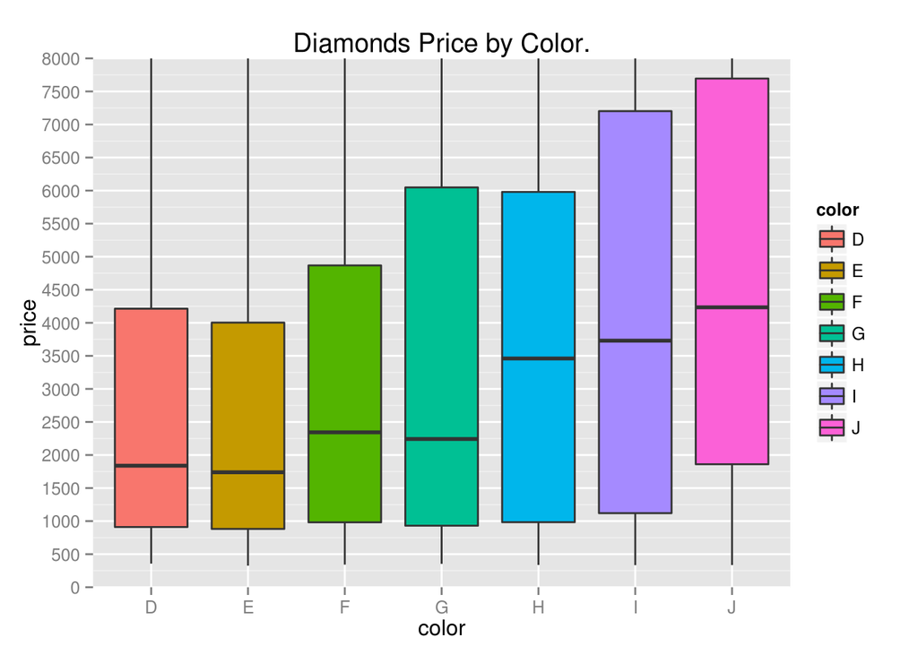

```r
ggplot(diamonds) + geom_boxplot(aes(x = color,  y = price, fill = color)) +
  coord_cartesian(ylim = c(0, 8000)) +
  scale_y_continuous(breaks = seq(0,8000,500)) +
  ggtitle("Diamonds Price by Color.")
```

### Excercise 11: Interquartile range - IQR

1. What is the price range for the middle 50% of diamonds with color D?

```r
by(diamonds$price, diamonds$color, summary)
```

```
## diamonds$color: D
##    Min. 1st Qu.  Median    Mean 3rd Qu.    Max.
##     357     911    1838    3170    4214   18690
## --------------------------------------------------------
## diamonds$color: E
##    Min. 1st Qu.  Median    Mean 3rd Qu.    Max.
##     326     882    1739    3077    4003   18730
## --------------------------------------------------------
## diamonds$color: F
##    Min. 1st Qu.  Median    Mean 3rd Qu.    Max.
##     342     982    2344    3725    4868   18790
## --------------------------------------------------------
## diamonds$color: G
##    Min. 1st Qu.  Median    Mean 3rd Qu.    Max.
##     354     931    2242    3999    6048   18820
## --------------------------------------------------------
## diamonds$color: H
##    Min. 1st Qu.  Median    Mean 3rd Qu.    Max.
##     337     984    3460    4487    5980   18800
## --------------------------------------------------------
## diamonds$color: I
##    Min. 1st Qu.  Median    Mean 3rd Qu.    Max.
##     334    1120    3730    5092    7202   18820
## --------------------------------------------------------
## diamonds$color: J
##    Min. 1st Qu.  Median    Mean 3rd Qu.    Max.
##     335    1860    4234    5324    7695   18710
```

2. What is the price range for the middle 50% of diamonds with color J?

```r
by(diamonds$price, diamonds$color, summary)
```

```
## diamonds$color: D
##    Min. 1st Qu.  Median    Mean 3rd Qu.    Max.
##     357     911    1838    3170    4214   18690
## --------------------------------------------------------
## diamonds$color: E
##    Min. 1st Qu.  Median    Mean 3rd Qu.    Max.
##     326     882    1739    3077    4003   18730
## --------------------------------------------------------
## diamonds$color: F
##    Min. 1st Qu.  Median    Mean 3rd Qu.    Max.
##     342     982    2344    3725    4868   18790
## --------------------------------------------------------
## diamonds$color: G
##    Min. 1st Qu.  Median    Mean 3rd Qu.    Max.
##     354     931    2242    3999    6048   18820
## --------------------------------------------------------
## diamonds$color: H
##    Min. 1st Qu.  Median    Mean 3rd Qu.    Max.
##     337     984    3460    4487    5980   18800
## --------------------------------------------------------
## diamonds$color: I
##    Min. 1st Qu.  Median    Mean 3rd Qu.    Max.
##     334    1120    3730    5092    7202   18820
## --------------------------------------------------------
## diamonds$color: J
##    Min. 1st Qu.  Median    Mean 3rd Qu.    Max.
##     335    1860    4234    5324    7695   18710
```

3. What is the IQR for diamonds with the best color?

```r
by(diamonds$price, diamonds$color, IQR)
```

```
## diamonds$color: D
## [1] 3302.5
## --------------------------------------------------------
## diamonds$color: E
## [1] 3121
## --------------------------------------------------------
## diamonds$color: F
## [1] 3886.25
## --------------------------------------------------------
## diamonds$color: G
## [1] 5117
## --------------------------------------------------------
## diamonds$color: H
## [1] 4996.25
## --------------------------------------------------------
## diamonds$color: I
## [1] 6081.25
## --------------------------------------------------------
## diamonds$color: J
## [1] 5834.5
```

4. What is the IQR for diamonds with the worst color?

```r
by(diamonds$price, diamonds$color, IQR)
```

```
## diamonds$color: D
## [1] 3302.5
## --------------------------------------------------------
## diamonds$color: E
## [1] 3121
## --------------------------------------------------------
## diamonds$color: F
## [1] 3886.25
## --------------------------------------------------------
## diamonds$color: G
## [1] 5117
## --------------------------------------------------------
## diamonds$color: H
## [1] 4996.25
## --------------------------------------------------------
## diamonds$color: I
## [1] 6081.25
## --------------------------------------------------------
## diamonds$color: J
## [1] 5834.5
```

### Excercise 12: Price per Carat Box Plots by Color

Investigate the price per carat of diamonds across the different colors of diamonds using boxplots.

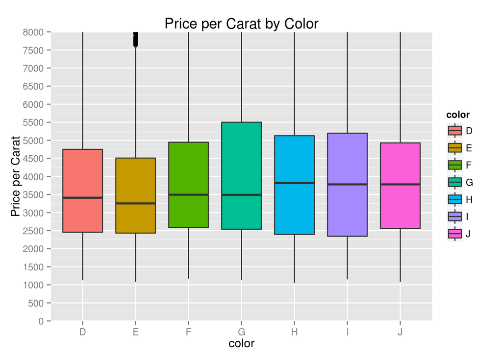

```r
ggplot(diamonds) + geom_boxplot(aes(x=color,y=price/carat, fill=color)) +
  scale_y_continuous(breaks = seq(0,8000,500)) +
  coord_cartesian(ylim = c(0,8000)) +
  ylab("Price per Carat") +
  ggtitle("Price per Carat by Color")
```

### Carat frequency polygon

Investigate the weight of the diamonds (carat) using a frequency polygon. Use different bin widths to see how the frequency polygon changes. What carat size has a count greater than 2000?

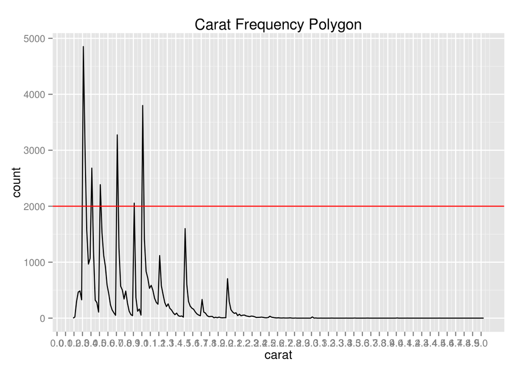

```r
ggplot(diamonds) + geom_freqpoly(aes(x = carat), binwidth = 0.02) +
  scale_x_continuous(breaks = seq(0,5,0.1)) +
  geom_hline(y = 2000,color = "red") +
  ggtitle("Carat Frequency Polygon")
```

### Gapminder Data

The Gapminder website contains over 500 data sets with information about the world’s population. Your task is to download a data set of your choice and create 2-5 plots that make use of the techniques from Lesson 3.

You might use a simple histogram, a boxplot split over a categorical variable, or a frequency polygon. The choice is yours!

You can find a link to the Gapminder website in the Instructor Notes.

Once you’ve completed your investigation, create a post in the discussions that includes: 1. any questions you answered, your observations, and summary statistics 2. snippets of code that created the plots 3. links to the images of your plots

##### Download and Cleaning data

```r
library(reshape2)
library(plyr)
setwd("~/Repos/data-analysis-with-r/")
file.path <- "./data/indicator_forest coverage.csv"
data <- read.csv(file.path,col.names = c("Country","1990","2000","2005"))

data <- melt(data, id.vars = c("Country"))
names(data) <- c("Country","Year","Forest.Coverage")

data$Year <- gsub("X","",data$Year)
data$Year <- as.factor(data$Year)

data$Forest.Coverage <- gsub(",",".",data$Forest.Coverage)
data$Forest.Coverage <- as.numeric(data$Forest.Coverage,na.action)
```

#### Data Processing

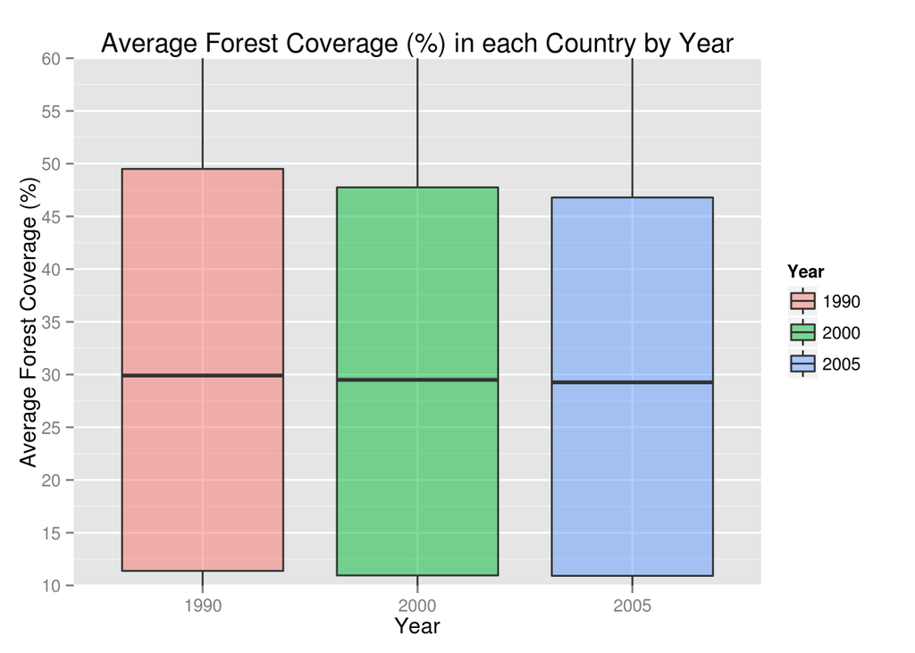

```r
ggplot(data) +
  geom_boxplot(aes(x = Year, y = Forest.Coverage, fill = Year), alpha = 0.5) +
  scale_y_continuous(breaks = seq(0,60,5)) +
  coord_cartesian(ylim = c(10,60)) +
  ylab("Average Forest Coverage (%)") +
  ggtitle("Average Forest Coverage (%) in each Country by Year")
```

##### Argentina:

```r
argentina <- subset(data, Country == "Argentina")
argentina
```

```
##       Country Year Forest.Coverage
## 215 Argentina 1990           12.88
## 444 Argentina 2000           12.34
## 673 Argentina 2005           12.07
```

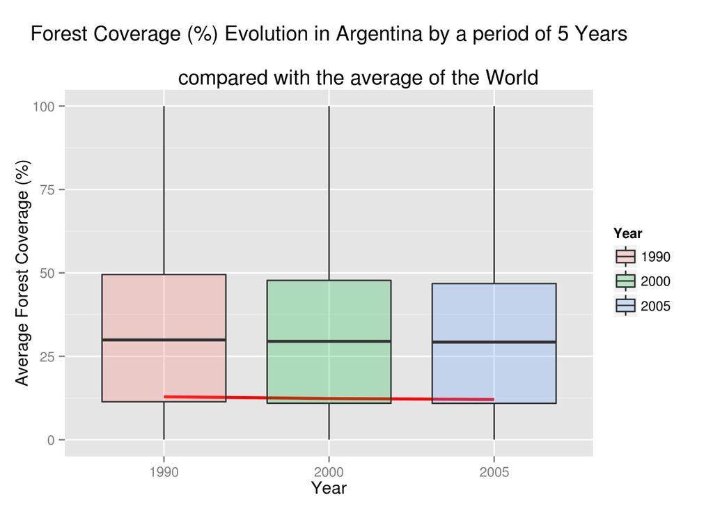

```r
ggplot(argentina) +
  geom_line(aes(x=Year,y=Forest.Coverage, group = Country), stat= "identity",
            size = 1, color = "red") +
  geom_boxplot(data = data , aes(x=Year,y=Forest.Coverage, fill = Year), alpha = 0.25) +
  ggtitle("Forest Coverage (%) Evolution in Argentina by a period of 5 Years\n
          compared with the average of the World") +
  ylab("Average Forest Coverage (%)")
```

Argentina’s Forest Coverage went down from 12.88% to 12.07%. Argentina’s values are limiting the First Quartile of the entire population.

##### South America

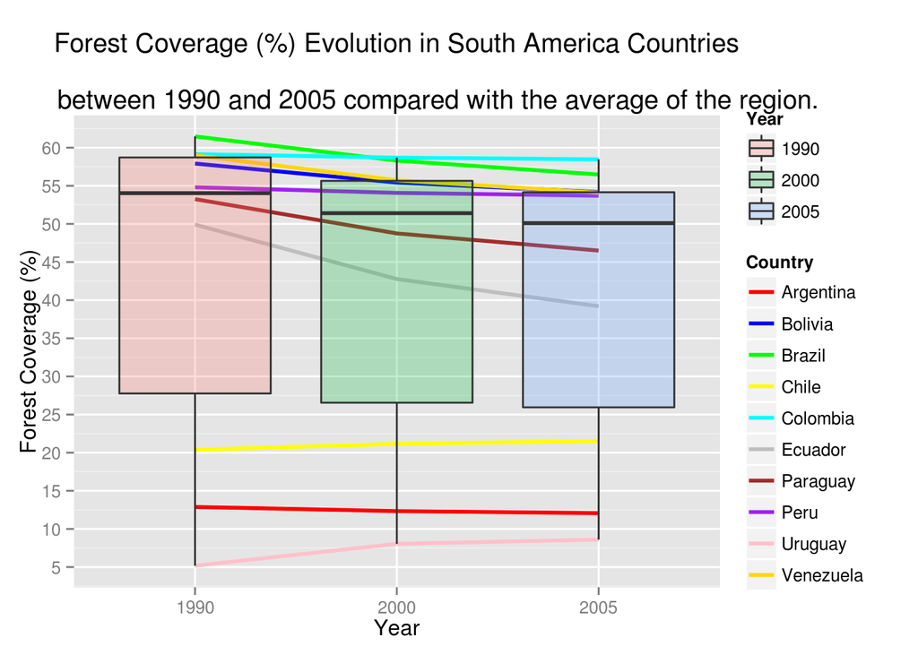

```r
south.america <- c("Argentina", "Chile", "Uruguay", "Paraguay", "Brazil",
                   "Peru", "Ecuador", "Bolivia", "Venezuela", "Colombia")

south.america.data <- subset(data, Country %in% south.america)
ggplot(south.america.data) +
  geom_line(aes(x=Year,y=Forest.Coverage, group = Country,
                color = Country),
            stat= "identity", size = 1) +
  ggtitle("Forest Coverage (%) Evolution in South America Countries\n
           between 1990 and 2005 compared with the average of the region.") +
  geom_boxplot(aes(x=Year,y=Forest.Coverage, fill = Year), alpha = 0.25) +
  ylab("Forest Coverage (%)") +
  scale_colour_manual(values = c("red","blue", "green", "yellow", "cyan", "grey",
                                 "brown", "purple", "pink", "gold")) +
  scale_y_continuous(breaks = seq(0,70,5))
```

##### G20 Countries

I’ve excluded European Union and South Korea due to missing values in the Data Set

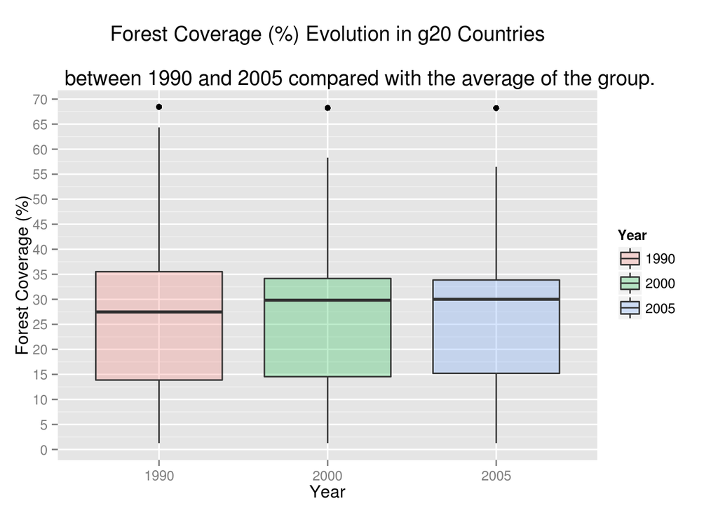

```r
g20 <- c("Argentina","Australia", "Brazil","Canada","China","France",
                   "Germany", "India", "Indonesia","Italy", "Japan","Mexico",
                   "Russia", "Saudi Arabia", "South Africa",
                   "Turkey", "United Kingdom", "United States")

g20.data <- subset(data, Country %in% g20)
ggplot(g20.data) +
  ggtitle("Forest Coverage (%) Evolution in g20 Countries\n
           between 1990 and 2005 compared with the average of the group.") +
  geom_boxplot(aes(x=Year,y=Forest.Coverage, fill = Year), alpha = 0.25) +
  ylab("Forest Coverage (%)") +
  scale_y_continuous(breaks = seq(0,70,5))
```

##### G20 Countries that increased its Forest Coverage

```r
# Calculate de Difference Between FC in 2005 and FC in 1990.
Evolution <- subset(g20.data, Year == 2005)$Forest.Coverage - subset(g20.data, Year == 1990)$Forest.Coverage
# Get the list of Countries
Country <- subset(g20.data, Year == 2005)$Country
# Create the Data Frame
g20.evolution <- data.frame(Country, Evolution)
# Order the Data Frame by Evolution
g20.evolution <- arrange(g20.evolution,Evolution,decreasing = T)
# Reset the Factors levels so ggplot can plot in correct order
g20.evolution$Country <- factor(g20.evolution$Country,
                                      levels = g20.evolution$Country)
g20.evolution
```

```
##           Country Evolution
## 1           Italy      5.43
## 2           China      4.30
## 3          France      1.84
## 4           India      1.26
## 5  United Kingdom      0.97
## 6         Germany      0.96
## 7          Turkey      0.64
## 8   United States      0.48
## 9    South Africa      0.00
## 10   Saudi Arabia      0.00
## 11         Canada      0.00
## 12         Russia     -0.01
## 13          Japan     -0.23
## 14      Australia     -0.55
## 15      Argentina     -0.81
## 16         Mexico     -2.50
## 17         Brazil     -5.00
## 18      Indonesia    -15.50
```

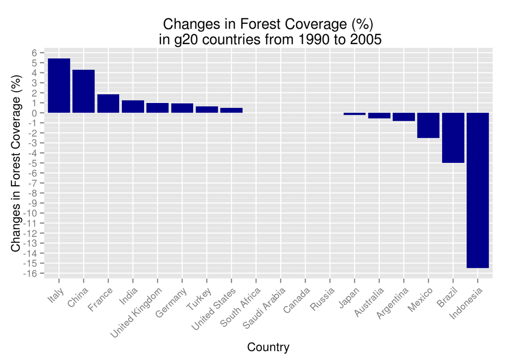

```r
ggplot(g20.evolution) +
  geom_bar(aes(x=Country,y=Evolution), fill = "blue4", stat = "identity") +
  scale_y_continuous(breaks = seq(-20,15,1)) +
  ggtitle("Changes in Forest Coverage (%)\n in g20 countries from 1990 to 2005") +
  ylab("Changes in Forest Coverage (%)") +
  theme(axis.text.x = element_text(angle = 45, hjust = 1))
```

Some interesting results: - Italy, China, France, India, United Kingdom, Germany, Turkey and United States **increased** their Forest Coverage from 1990 to 2005 - Japan, Australia, Argentina, Mexico, Brazil, and Indonesia **decreased** their Forest Coverage between 1900 and 2005

##### Top Countries in the World 2005

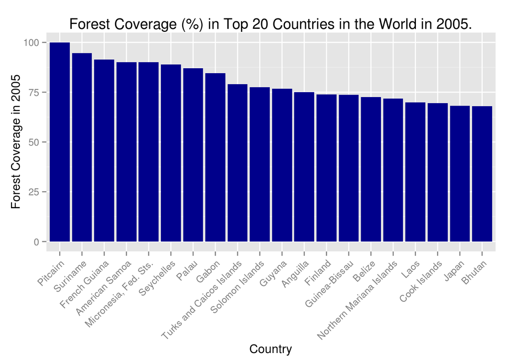

```r
top.countries.2005 <- subset(data, Year == 2005)
top.countries.2005 <- top.countries.2005[order(top.countries.2005$Forest.Coverage,
                                               decreasing = T),]

top.countries.2005$Country <- factor(top.countries.2005$Country,
                                     levels = top.countries.2005$Country)
# Plot Top 20
ggplot(top.countries.2005[1:20,]) +
  geom_bar(aes(x=Country, y = Forest.Coverage), fill = "blue4", stat = "identity") +
  ylab("Forest Coverage in 2005") +
  ggtitle("Forest Coverage (%) in Top 20 Countries in the World in 2005.") +
  theme(axis.text.x = element_text(angle = 45, hjust = 1))
```

###### Top Evolution in Forest Coverage in the World

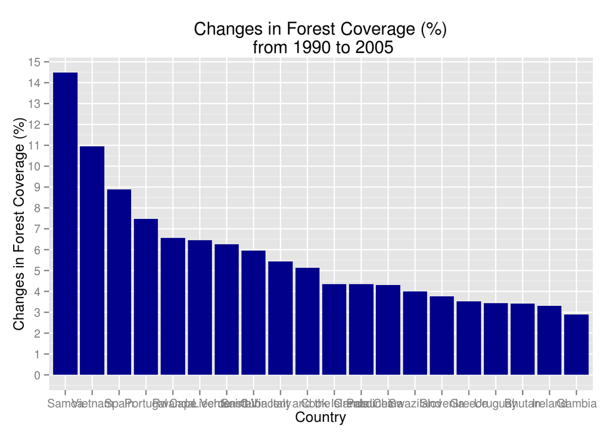

```r
Country <- as.character(unique(data$Country))
Evolution <- subset(data, Year == 2005)$Forest.Coverage - subset(data, Year == 1990)$Forest.Coverage

countries.evolution <- data.frame(Country, Evolution)
countries.evolution <- arrange(countries.evolution,Evolution,decreasing = T)
countries.evolution$Country <- factor(countries.evolution$Country,
                                      levels = countries.evolution$Country)

ggplot(countries.evolution[1:20,]) +
  geom_bar(aes(x=Country,y=Evolution), fill = "blue4", stat = "identity") +
  scale_y_continuous(breaks = seq(-11,15,1)) +
  ggtitle("Changes in Forest Coverage (%)\n from 1990 to 2005") +
  ylab("Changes in Forest Coverage (%)")
```

```r
library(rworldmap)
library(RColorBrewer)

colourPalette <- brewer.pal(7,"Greens")
sPDF <- joinCountryData2Map( countries.evolution, joinCode = "NAME",
                             nameJoinColumn = "Country")
```

```
## 213 codes from your data successfully matched countries in the map
## 16 codes from your data failed to match with a country code in the map
## 31 codes from the map weren't represented in your data
```

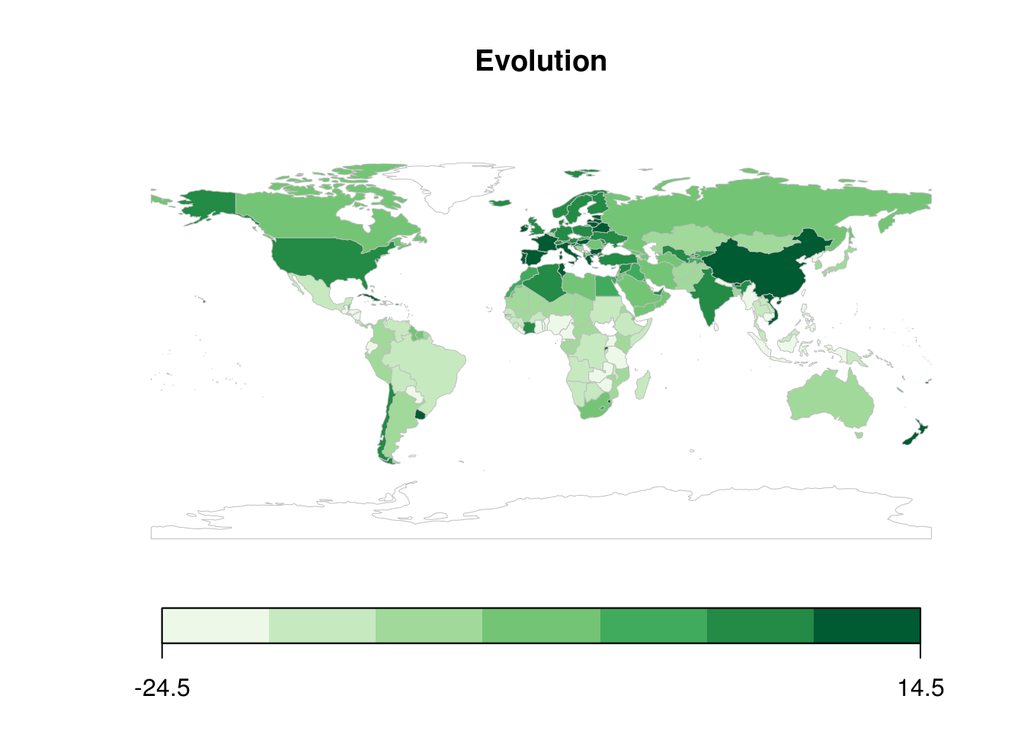

```r
mapCountryData( sPDF, nameColumnToPlot="Evolution",
                   colourPalette = colourPalette )
```